# Processing data for plotting across the antimeridian with vector data

Author

Jeet Sukumaran

```julia
using GeoMakie, CairoMakie
```

**Proficiencies**

1. Explain why antimeridian artifacts arise from coordinate wrap-around in raw longitude data.
2. Normalize longitude coordinates to a target central meridian using a modular remapping function.
3. Insert `NaN` breaks into coordinate arrays to prevent false line segments across antimeridian crossings.
4. Compute the exact latitude of an antimeridian crossing and split a linestring into two correctly-terminated segments.

The antimeridian artifacts that arise when centering a projection on $180°$ are a symptom of a more general problem: longitude values in the standard $[-180°, 180°]$ range are not *continuous* with respect to an arbitrary map center $\lambda_0$. A segment whose two endpoints have longitudes of $170°$ and $-170°$ spans only $20°$ of arc in reality, but their coordinate difference is $340°$ — and the renderer, knowing nothing about spherical topology, draws a line spanning nearly the full width of the plot. The same problem arises whenever your data straddle the longitude that lies $180°$ from $\lambda_0$: centering on $-100°$ (central North America) causes artifacts near $80°\,\text{E}$, for instance.

Fixing the problem requires two distinct operations, depending on the geometry type:

1. **Longitude normalization** — remapping each coordinate so that it falls within $[\lambda_0 - 180°,\ \lambda_0 + 180°]$. This alone resolves artifacts in scattered point data and in linestrings whose individual vertices do not cross the boundary.
2. **Segment breaking or splitting** — detecting segments that *still* cross the boundary after normalization and either inserting a `NaN` break (suppressing the crossing segment) or computing the exact crossing latitude and splitting the geometry into two correctly-terminated pieces.

## 1 Longitude normalization

The standard longitude domain $[-180°, 180°]$ is just one period of a circular quantity. For a map centered on $\lambda_0$, the appropriate domain is $[\lambda_0 - 180°,\ \lambda_0 + 180°]$. Remapping a longitude $\lambda$ into this domain is a single modular arithmetic operation:

$$\lambda' = \bigl((\lambda - \lambda_0 + 180) \bmod 360\bigr) - 180 + \lambda_0$$

```julia
"""
    normalize_lon(lon, lon_0=0.0)

Remap longitude `lon` (degrees) into the half-open interval
`[lon_0 - 180, lon_0 + 180)`, preserving its position on the circle.
"""
normalize_lon(lon, lon_0=0.0) = mod(lon - lon_0 + 180.0, 360.0) - 180.0 + lon_0
```

**1**

`mod(x, 360)` returns a value in $[0°, 360°)$; subtracting $180°$ and re-centering on `lon_0` shifts this into $[\lambda_0 - 180°, \lambda_0 + 180°)$.

```
Main.Notebook.normalize_lon
```

For a vector of longitudes associated with point observations, broadcasting normalization is sufficient:

```julia
lon_0 = 180.0
lons_raw = [160.0, 175.0, -175.0, -160.0, -90.0]
lats_raw = [-10.0,  -5.0,   -5.0,  -10.0,  20.0]

lons_norm = normalize_lon.(lons_raw, lon_0)

fig = Figure()
ax  = GeoAxis(fig[1, 1]; dest="+proj=eqearth +lon_0=$(lon_0)")
lines!(ax, GeoMakie.coastlines(ax))
scatter!(ax, lons_norm, lats_raw)
fig
```

**1**

Central meridian of the destination projection.

**2**

Raw longitudes spanning the antimeridian: without normalization, the points near $\pm175°$ would appear on opposite sides of the map.

**3**

Broadcast `normalize_lon` over every longitude in the vector.

**4**

Pass the *normalized* longitudes to the plotting call; the axis applies only the final CRS transformation, not any wrapping correction.

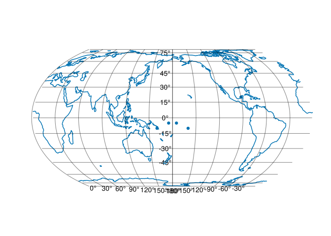